Skip to main content

# Publication figure report

Author

Affiliation

none

manual

**Important**

A manual command generated this report without an LLM model. No separate human scientific review is part of this fixed recipe. The report records the selected recipe and does not claim a new statistical method.

## Figure

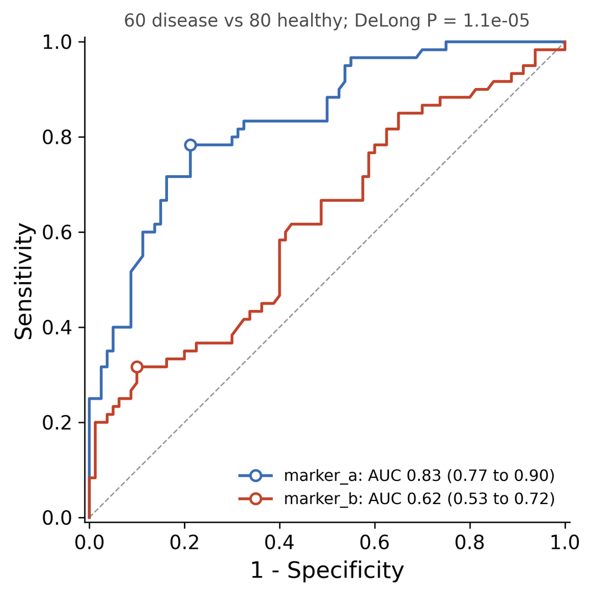

Publication figure

## Statistical results

| marker | case_level | n_cases | n_controls | direction | auc | auc_ci_low | auc_ci_high | youden_threshold | sensitivity | specificity | constant_marker | complete_separation | delong_z_vs_first | delong_p_vs_first |
| --- | --- | --- | --- | --- | --- | --- | --- | --- | --- | --- | --- | --- | --- | --- |
| marker_a | disease | 60 | 80 | < | 0.8339583333333335 | 0.767585790501013 | 0.9003308761656539 | 3.975 | 0.7833333333333333 | 0.7875 | FALSE | FALSE |  |  |
| marker_b | disease | 60 | 80 | < | 0.6213541666666667 | 0.5266651760981201 | 0.7160431572352132 | 10.835 | 0.31666666666666665 | 0.9 | FALSE | FALSE | 4.404296741345254 | 1.0612759207215801e-05 |

## Methods

Receiver operating characteristic (ROC) curves were computed for the discrimination of status = disease (cases, n = 60) from healthy (controls, n = 80). The area under each curve (AUC) is reported with a 95% confidence interval by the method of DeLong et al. (1988), and the optimal threshold maximises the Youden index (sensitivity + specificity - 1). marker_a, AUC = 0.834 (95% CI 0.768 to 0.900), optimal threshold 3.975 (sensitivity 0.78, specificity 0.79); marker_b, AUC = 0.621 (95% CI 0.527 to 0.716), optimal threshold 10.84 (sensitivity 0.32, specificity 0.90). The AUC of each marker was compared with that of marker_a by DeLong’s test for two correlated ROC curves: marker_b, Z = 4.40, P = 1.1e-05. Computed in Python 3.10.12 with numpy 1.26.4 and scipy 1.15.3, following the rules of pROC, and drawn with matplotlib 3.10.9.

## Plot configuration

The complete plot configuration is in `plot_config.yaml`.

## Provenance

| field | value |
| --- | --- |
| repository | pubready |
| repository_version | 4.0.0 |
| git_commit | 567ce8900bdb5db88369d131c8d787b042b3af57 |
| git_dirty | FALSE |
| llm_provider | none |
| llm_model | none |
| agent_harness | manual |
| agent_harness_version | not_recorded |
| container_image | localhost/pubready:4.0.0 |
| container_digest | sha256:0f57027a3fbca5ec9d41d74ca91226fbdf45d94b1a85f271637d12733db5d483 |
| input | {“file”: “input_status_marker_a_marker_b.csv”, “md5”: “f6d3a1a52479ba12f8a4ee2644beb33d”, “sha256”: “093cd3826f05f33eb5db7e8f7d1b571a2e2c02a398727171a5702f39ecce3fa7”} |
| command | figkit plot –recipe roc_curve |
| analysis_options | {“engine”: “python”, “recipe”: “roc_curve”, “data”: {“file”: “biomarker_roc.csv”, “x”: “marker_a,marker_b”, “y”: “status”, “fill”: null, “facet”: null, “time”: null, “event”: null, “annotation”: null,… |
| random_seeds | not_applicable |
| session_record | session_info.txt |
| created_utc | 2026-07-18T00:00:00Z |
| review_state | not_applicable |
| reviewer | none |
| quarto_version | 1.11.4 |

The report source reads only files in this bundle.